# Sequence Patterns, Outcomes, and Indices with `codyna`

A Tutorial on dynamics of behavior with `codyna`

tutorial

R

Authors

Affiliation

[Mohammed Saqr](https://saqr.me)

University of Eastern Finland

[Sonsoles López-Pernas](https://sonsoles.me)

University of Eastern Finland

Published

February 14, 2026

# 1 Exploring Sequences

Learning unfolds as an ordered sequence of states—engagement levels across weeks, problem-solving actions within a session, regulatory behaviors during collaboration. Sequence analysis preserves this temporal ordering rather than collapsing it into a single summary. The approach originated in molecular biology for comparing DNA sequences and was adapted for the social sciences by Abbott (1995). In education, it has been used to study course-taking trajectories, self-regulated learning strategies, and collaborative regulation dynamics (Saqr et al., 2024a).

From a complex dynamic systems perspective, learners exhibit feedback loops, attractor states, and phase transitions (Saqr et al., 2025a). A student’s trajectory is not a random walk—disengagement breeds more disengagement, and current states affect next ones as well as sudden shifts from one stable regime to another are common. Sequence-level analysis captures these dynamics at the individual level, complementing the aggregate view provided by transition models.

**TipCompanion tutorials**

This tutorial is part of a series on tutorials on dynamics of learning and learners using Transition Network Analysis with the `tna` and `codyna` R packages:

1. **[Transition Network Analysis with R](https://sonsoles.me/posts/tna-tutorial/)** — building, visualizing, and interpreting TNA models; centrality, communities, bootstrapping.
2. **[TNA Group Analysis](https://sonsoles.me/posts/tna-group/)** — analysis and comparison of groups.
3. **[TNA Clustering](https://sonsoles.me/posts/tna-clustering/)** — discovering and analyzing clusters of sequences.
4. **[TNA Model Comparison](https://sonsoles.me/posts/tna-compare/)** — edge-level, summary, centrality, and network-level comparison; permutation tests.
5. **Sequence Patterns, Outcomes, and Indices** (this tutorial) — pattern discovery, outcome modeling, and structural indices with `codyna`.

Package website: https://sonsoles.me/tna/

**NoteWhat is sequence analysis?**

Sequence analysis is a family of methods for studying ordered categorical data. In education, the “sequence” is typically a student’s trajectory through a series of states measured at successive time points.

Three levels of analysis are possible:

1. **Sequence visualization**: plotting individual trajectories and state distributions to see the raw data before modeling.
2. **Sequence indices**: computing per-sequence summary measures (entropy, stability, complexity) that characterize *how* each sequence unfolds.
3. **Pattern discovery**: identifying recurring sub-sequences (n-grams, gapped patterns) that tell us *what* specific pathways students follow.

This tutorial works with three datasets, each illustrating different scenarios of sequence analysis. Before analyzing any dataset, we visualize it—distribution plots and frequency plots establish the context that makes pattern and index results interpretable.

Table 1: Datasets used in this tutorial

| Dataset | Source | Sequences | States | Time points | Used for |
| --- | --- | --- | --- | --- | --- |
| `group_regulation` | `tna` package | 2,000 | 9 (collaborative regulation) | up to 26 | N-gram examples with filtering |
| **Codyna** | `Codyna.RDS` | 5,000 | 10 (math exercise actions) | up to 10 | Pattern discovery, outcome modeling |
| `engagement` | `codyna` package | 1,000 | 3 (Active, Average, Disengaged) | 25 | Sequence indices |

## 1.1 Visualizing the regulation data

The first step with any dataset is to visualize it. We begin with the `group_regulation` dataset—2,000 collaborative regulation sequences with 9 states. TNA provides tools for preparing and visualizing event data. We will use TNA here to prepare the data but we will focus on the sequences not the network analysis.

```r
data("group_regulation_long", package = "tna")
prepared <- prepare_data(
  group_regulation_long,
  action = "Action", actor = "Actor", time = "Time"
)
```

Having prepared the data we can explore it with sequence analysis and visualize the sequence. TNA comes with several methods for plotting and incldueds sequence plots. Here we will use distribution plots. A state distribution plot aggregates individual trajectories into proportions at each time point:

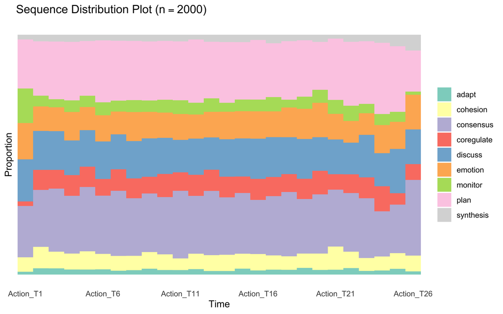

Figure 1: State proportions over time. The roughly flat distribution indicates a stationary process—no strong temporal trend.

```r
plot_sequences(prepared, type = "distribution", scale = "proportion")
```

Also, TNA includes tools for plot state frequencies, so you don’t have to manually do it. A frequency plot shows overall state prevalence—the marginal baseline for interpreting lift later:

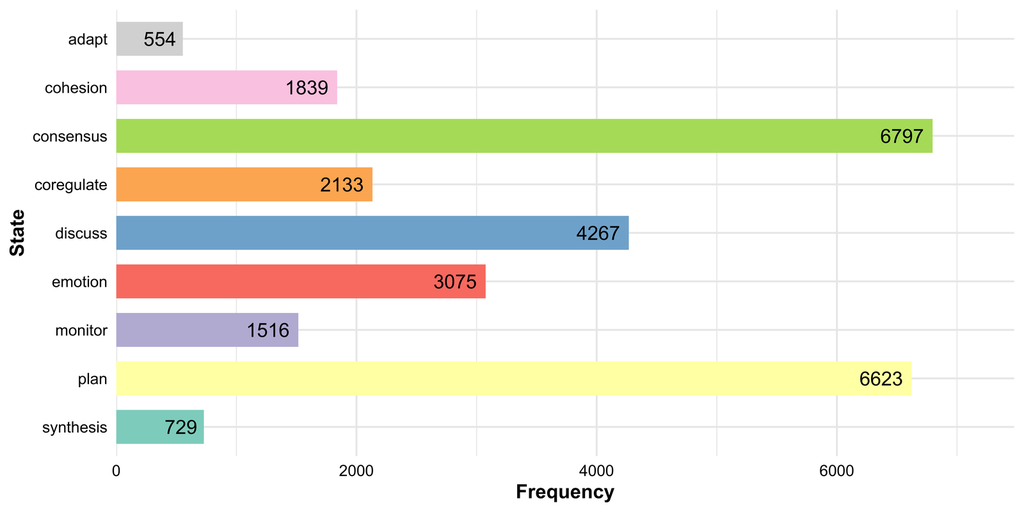

Figure 2: State frequencies. Consensus and plan dominate; synthesis and adapt are rare.

```r
model_reg <- tna(prepared)
plot_frequencies(model_reg)
```

## 1.2 Visualizing the problem-solving data

Each row is one problem attempt with up to 10 steps.

```r
codyna_long <- data.frame(
  id = rep(seq_len(nrow(codyna_data)), each = ncol(codyna_data)),
  time = rep(seq_len(ncol(codyna_data)), nrow(codyna_data)),
  action = as.vector(t(as.matrix(codyna_data)))
)
codyna_long <- codyna_long[!is.na(codyna_long$action), ]
prepared_codyna <- prepare_data(codyna_long, action = "action", actor = "id", time = "time")
```

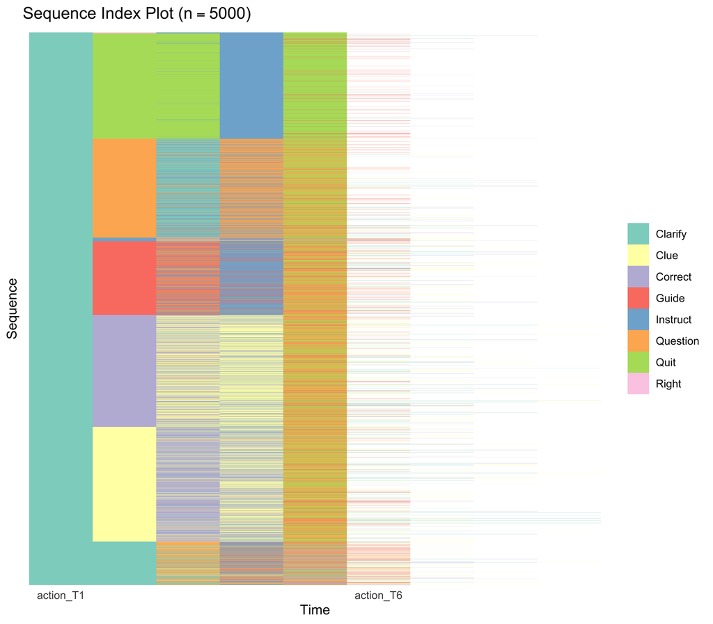

```r
plot_sequences(prepared_codyna, sort_by ="action_T2")
```

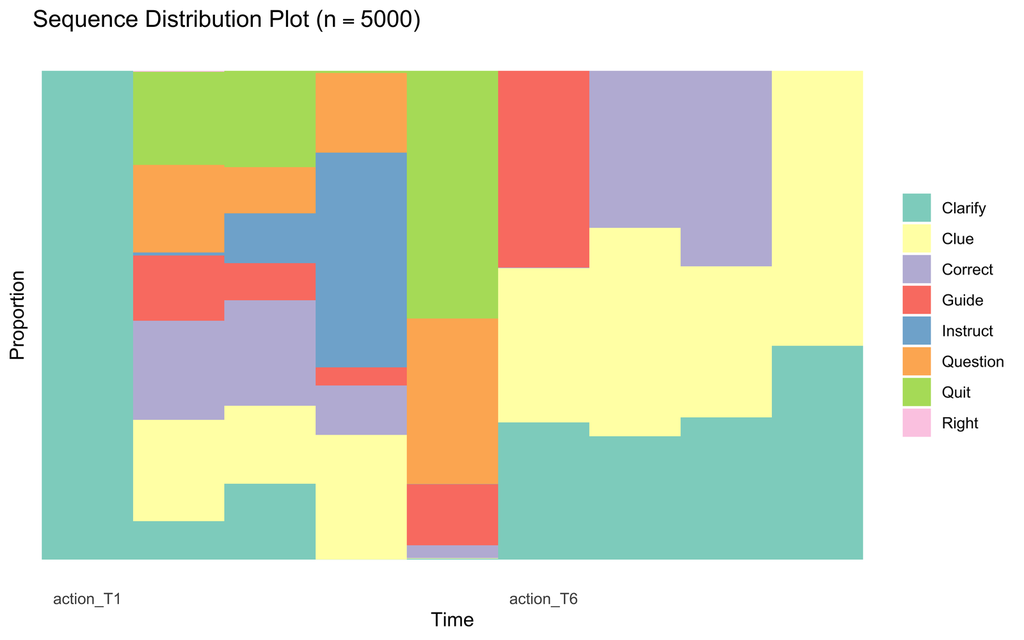

```r
plot_sequences(prepared_codyna, type = "distribution", scale = "proportion")
```

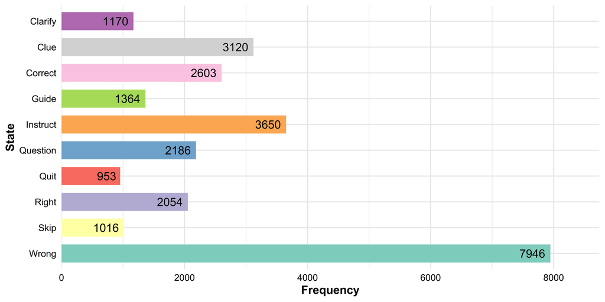

Figure 5: State frequencies across all time points. Instruct and Wrong dominate; Right and Correct are less frequent.

```r
model_codyna <- tna(prepared_codyna)
plot_frequencies(model_codyna)
```

# 2 Pattern Discovery

TNA builds a transition matrix from all sequences, revealing which pairwise transitions are most probable. Pattern discovery complements this by examining each sequence individually—identifying the specific multi-step sub-sequences that recur across students. Longer pathways like Wrong→Quit→Skip→Instruct→Wrong extend the picture to five-step chains. Patterns can also be linked to outcomes—not just which pathways exist, but which predict success or failure which offers a unique perspective and new functionality that no other package provides.

## 2.1 N-grams

TNA already captures pairwise transitions (length 2), so the value of n-grams begins at length 3 and above. We start with the regulation data. A TNA model would show consensus→plan and plan→consensus as the two strongest edges. Do these chain into sustained multi-step pathways within the same sequences?

```r
data("group_regulation")
reg_ngrams <- discover_patterns(group_regulation, type = "ngram", len = 3:5)
reg_ngrams
```

|  | pattern | length | frequency | proportion | count | support | lift |
| --- | --- | --- | --- | --- | --- | --- | --- |
| 1 | consensus->plan->plan | 3 | 877 | 0.04140 | 703 | 0.351 | 0.522 |
| 2 | plan->plan->plan | 3 | 792 | 0.03739 | 454 | 0.227 | 0.358 |
| 3 | consensus->plan->consensus | 3 | 686 | 0.03238 | 554 | 0.277 | 0.387 |
| 4 | plan->consensus->plan | 3 | 643 | 0.03035 | 490 | 0.245 | 0.364 |
| 5 | plan->plan->consensus | 3 | 619 | 0.02922 | 525 | 0.263 | 0.390 |
| 6 | discuss->consensus->plan | 3 | 483 | 0.02280 | 439 | 0.220 | 0.355 |
| 7 | emotion->cohesion->consensus | 3 | 399 | 0.01884 | 364 | 0.182 | 0.469 |
| 8 | consensus->discuss->consensus | 3 | 378 | 0.01784 | 318 | 0.159 | 0.242 |
| 9 | consensus->plan->emotion | 3 | 341 | 0.01610 | 298 | 0.149 | 0.257 |
| 10 | plan->consensus->coregulate | 3 | 331 | 0.01563 | 300 | 0.150 | 0.316 |

[output cut: 546 more lines]

Top n-grams (lengths 3–5) from collaborative regulation sequences

**NoteOutput columns**

- **Frequency**: total occurrences across all sequences (one sequence can contribute multiple instances).
- **Count**: number of sequences containing the pattern at least once.
- **Support**: count / total sequences—the proportion containing the pattern. Use this to compare across datasets of different sizes.
- **Lift**: observed support / expected support under independence. Above 1 = over-represented; below 1 = under-represented (Agrawal et al., 1993).
- **Proportion**: pattern’s share of total frequency at its length.

**What follows planning?** The `start` parameter isolates pathways originating from a given state:

```r
reg_plan <- discover_patterns(group_regulation, type = "ngram", len = 3:4, start = "plan")
reg_plan
```

|  | pattern | length | frequency | proportion | count | support | lift |
| --- | --- | --- | --- | --- | --- | --- | --- |
| 1 | plan->plan->plan | 3 | 792 | 0.1453 | 454 | 0.227 | 0.358 |
| 2 | plan->consensus->plan | 3 | 643 | 0.1180 | 490 | 0.245 | 0.364 |
| 3 | plan->plan->consensus | 3 | 619 | 0.1136 | 525 | 0.263 | 0.390 |
| 4 | plan->consensus->coregulate | 3 | 331 | 0.0607 | 300 | 0.150 | 0.316 |
| 5 | plan->plan->emotion | 3 | 301 | 0.0552 | 285 | 0.142 | 0.261 |
| 6 | plan->consensus->discuss | 3 | 278 | 0.0510 | 257 | 0.129 | 0.208 |
| 7 | plan->plan->plan->plan | 4 | 278 | 0.0749 | 168 | 0.084 | 0.154 |
| 8 | plan->emotion->consensus | 3 | 274 | 0.0503 | 257 | 0.129 | 0.221 |
| 9 | plan->emotion->cohesion | 3 | 268 | 0.0492 | 245 | 0.122 | 0.335 |
| 10 | plan->plan->consensus->plan | 4 | 233 | 0.0628 | 217 | 0.108 | 0.188 |

[output cut: 87 more lines]

Planning leads three ways: sustained planning (plan→plan→plan, support = 0.23), cycling back to consensus (plan→consensus→plan, support = 0.24), and emotional reactions (plan→plan→emotion, support = 0.14). The first two sustain the task; the third signals that extended planning sometimes triggers affect.

**What follows consensus?**

```r
reg_cons <- discover_patterns(group_regulation, type = "ngram", len = 3:4, start = "consensus")
reg_cons
```

|  | pattern | length | frequency | proportion | count | support | lift |
| --- | --- | --- | --- | --- | --- | --- | --- |
| 1 | consensus->plan->plan | 3 | 877 | 0.1557 | 703 | 0.351 | 0.522 |
| 2 | consensus->plan->consensus | 3 | 686 | 0.1218 | 554 | 0.277 | 0.387 |
| 3 | consensus->discuss->consensus | 3 | 378 | 0.0671 | 318 | 0.159 | 0.242 |
| 4 | consensus->plan->emotion | 3 | 341 | 0.0605 | 298 | 0.149 | 0.257 |
| 5 | consensus->plan->plan->plan | 4 | 305 | 0.0787 | 276 | 0.138 | 0.239 |
| 6 | consensus->coregulate->discuss | 3 | 301 | 0.0534 | 273 | 0.137 | 0.313 |
| 7 | consensus->coregulate->plan | 3 | 257 | 0.0456 | 238 | 0.119 | 0.250 |
| 8 | consensus->plan->plan->consensus | 4 | 233 | 0.0601 | 214 | 0.107 | 0.174 |
| 9 | consensus->plan->consensus->plan | 4 | 228 | 0.0588 | 202 | 0.101 | 0.164 |
| 10 | consensus->discuss->discuss | 3 | 219 | 0.0389 | 206 | 0.103 | 0.182 |

[output cut: 100 more lines]

N-grams starting with consensus

```r
reg_emotion <- discover_patterns(group_regulation, type = "ngram", len = 3:4, contain = "emotion")
reg_emotion
```

|  | pattern | length | frequency | proportion | count | support | lift |
| --- | --- | --- | --- | --- | --- | --- | --- |
| 1 | emotion->cohesion->consensus | 3 | 399 | 0.0633 | 364 | 0.182 | 0.469 |
| 2 | consensus->plan->emotion | 3 | 341 | 0.0541 | 298 | 0.149 | 0.257 |
| 3 | emotion->consensus->plan | 3 | 320 | 0.0508 | 295 | 0.147 | 0.254 |
| 4 | plan->plan->emotion | 3 | 301 | 0.0478 | 285 | 0.142 | 0.261 |
| 5 | plan->emotion->consensus | 3 | 274 | 0.0435 | 257 | 0.129 | 0.221 |
| 6 | plan->emotion->cohesion | 3 | 268 | 0.0425 | 245 | 0.122 | 0.335 |
| 7 | consensus->coregulate->emotion | 3 | 195 | 0.0309 | 181 | 0.090 | 0.221 |
| 8 | emotion->consensus->discuss | 3 | 168 | 0.0267 | 161 | 0.081 | 0.151 |
| 9 | emotion->consensus->coregulate | 3 | 158 | 0.0251 | 151 | 0.075 | 0.184 |
| 10 | emotion->cohesion->consensus->plan | 4 | 149 | 0.0376 | 146 | 0.073 | 0.219 |

[output cut: 161 more lines]

N-grams involving emotion

emotion→cohesion→consensus (support = 0.18) is the dominant pathway. Emotional expression leads to social bonding and then group agreement—a three-step recovery arc invisible in the aggregate network, where emotion has weak edges to many states. Emotion feeds back into the consensus→plan cycle.

Now we apply the same approach to the math problem-solving data. With defaults, `discover_patterns()` extracts n-grams of length 2 through 5:

```r
ngrams <- discover_patterns(codyna_data)
ngrams
```

|  | pattern | length | frequency | proportion | count | support | lift |
| --- | --- | --- | --- | --- | --- | --- | --- |
| 1 | Instruct->Wrong | 2 | 1701 | 0.0819 | 1701 | 0.340 | 0.689 |
| 2 | Correct->Clue | 2 | 1393 | 0.0671 | 1393 | 0.279 | 1.897 |
| 3 | Instruct->Instruct | 2 | 1166 | 0.0562 | 813 | 0.163 | 0.667 |
| 4 | Wrong->Clue | 2 | 1037 | 0.0499 | 1037 | 0.207 | 0.525 |
| 5 | Skip->Instruct | 2 | 1016 | 0.0489 | 1016 | 0.203 | 2.026 |
| 6 | Wrong->Correct | 2 | 1014 | 0.0488 | 1014 | 0.203 | 0.545 |
| 7 | Clue->Correct | 2 | 1008 | 0.0485 | 1008 | 0.202 | 1.373 |
| 8 | Clarify->Question | 2 | 997 | 0.0480 | 997 | 0.199 | 3.202 |
| 9 | Wrong->Quit | 2 | 953 | 0.0459 | 953 | 0.191 | 1.000 |
| 10 | Quit->Skip | 2 | 934 | 0.0450 | 934 | 0.187 | 4.823 |

[output cut: 168 more lines]

Top 10 n-grams (default: lengths 2–5)

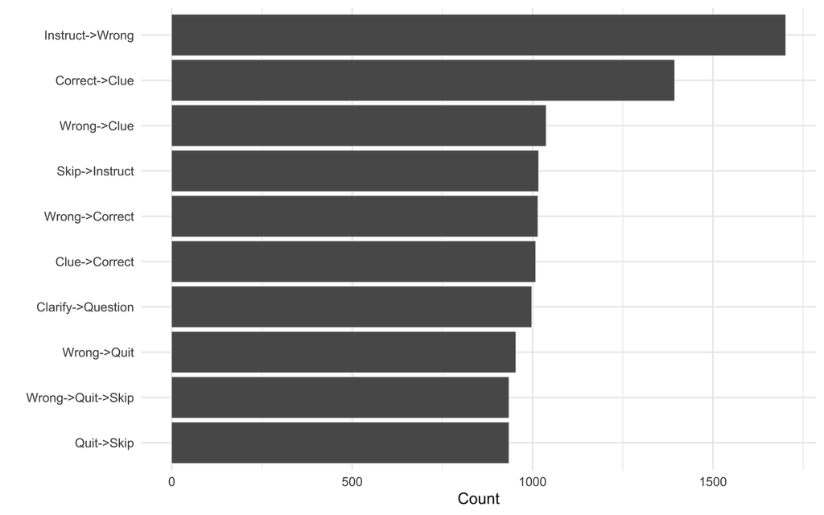

Top 10 n-grams by proportion.

```r
plot(ngrams, n = 10)
```

Trigrams (length 3) reveal multi-step pathways that bigrams cannot:

```r
trigrams <- discover_patterns(codyna_data, type = "ngram", len = 3)
trigrams
```

|  | pattern | length | frequency | proportion | count | support | lift |
| --- | --- | --- | --- | --- | --- | --- | --- |
| 1 | Wrong->Quit->Skip | 3 | 934 | 0.0613 | 934 | 0.187 | 4.823 |
| 2 | Quit->Skip->Instruct | 3 | 934 | 0.0613 | 934 | 0.187 | 9.771 |
| 3 | Skip->Instruct->Wrong | 3 | 927 | 0.0608 | 927 | 0.185 | 1.848 |
| 4 | Wrong->Clue->Correct | 3 | 729 | 0.0478 | 729 | 0.146 | 0.993 |
| 5 | Wrong->Question->Clarify | 3 | 641 | 0.0421 | 641 | 0.128 | 2.058 |
| 6 | Question->Clarify->Question | 3 | 640 | 0.0420 | 640 | 0.128 | 6.851 |
| 7 | Wrong->Correct->Clue | 3 | 559 | 0.0367 | 559 | 0.112 | 0.761 |
| 8 | Clue->Correct->Clue | 3 | 502 | 0.0329 | 502 | 0.100 | 1.732 |
| 9 | Instruct->Instruct->Wrong | 3 | 449 | 0.0295 | 449 | 0.090 | 0.369 |
| 10 | Correct->Clue->Wrong | 3 | 384 | 0.0252 | 384 | 0.077 | 0.523 |

[output cut: 50 more lines]

Top 10 trigrams (length 3)

Wrong→Quit→Skip has lift 4.82—nearly 5 times more frequent than expected. The bigrams Wrong→Quit and Quit→Skip each appear separately, but only the trigram reveals them as a single giving-up sequence. Extracting lengths 3 through 5 shows how the pathway extends:

```r
ngrams_range <- discover_patterns(codyna_data, type = "ngram", len = 3:5)
ngrams_range
```

|  | pattern | length | frequency | proportion | count | support | lift |
| --- | --- | --- | --- | --- | --- | --- | --- |
| 1 | Wrong->Quit->Skip | 3 | 934 | 0.0613 | 934 | 0.187 | 4.823 |
| 2 | Quit->Skip->Instruct | 3 | 934 | 0.0613 | 934 | 0.187 | 9.771 |
| 3 | Wrong->Quit->Skip->Instruct | 4 | 934 | 0.0998 | 934 | 0.187 | 9.771 |
| 4 | Skip->Instruct->Wrong | 3 | 927 | 0.0608 | 927 | 0.185 | 1.848 |
| 5 | Quit->Skip->Instruct->Wrong | 4 | 861 | 0.0920 | 861 | 0.172 | 9.008 |
| 6 | Wrong->Quit->Skip->Instruct->Wrong | 5 | 861 | 0.2138 | 861 | 0.172 | 9.008 |
| 7 | Wrong->Clue->Correct | 3 | 729 | 0.0478 | 729 | 0.146 | 0.993 |
| 8 | Wrong->Question->Clarify | 3 | 641 | 0.0421 | 641 | 0.128 | 2.058 |
| 9 | Question->Clarify->Question | 3 | 640 | 0.0420 | 640 | 0.128 | 6.851 |
| 10 | Wrong->Question->Clarify->Question | 4 | 639 | 0.0683 | 639 | 0.128 | 6.840 |

[output cut: 134 more lines]

Top 10 n-grams at lengths 3–5

At length 4, Wrong→Quit→Skip→Instruct (support = 0.19); at length 5, it adds →Wrong—a complete failure loop. Since most sequences are 5 steps long, length-5 n-grams capture entire trajectories:

```r
ngrams_5 <- discover_patterns(codyna_data, type = "ngram", len = 5)
ngrams_5
```

|  | pattern | length | frequency | proportion | count | support | lift |
| --- | --- | --- | --- | --- | --- | --- | --- |
| 1 | Wrong->Quit->Skip->Instruct->Wrong | 5 | 861 | 0.214 | 861 | 0.172 | 9.01 |
| 2 | Wrong->Question->Clarify->Question->Wrong | 5 | 335 | 0.083 | 335 | 0.067 | 3.59 |
| 3 | Wrong->Question->Clarify->Question->Right | 5 | 283 | 0.070 | 283 | 0.057 | 7.37 |
| 4 | Wrong->Clue->Correct->Clue->Wrong | 5 | 251 | 0.062 | 251 | 0.050 | 0.87 |
| 5 | Wrong->Clue->Correct->Clue->Right | 5 | 197 | 0.049 | 197 | 0.039 | 1.65 |
| 6 | Wrong->Correct->Clue->Clue->Right | 5 | 193 | 0.048 | 193 | 0.039 | 1.62 |
| 7 | Wrong->Correct->Correct->Clue->Right | 5 | 160 | 0.040 | 160 | 0.032 | 1.43 |
| 8 | Wrong->Correct->Clue->Clue->Wrong | 5 | 144 | 0.036 | 144 | 0.029 | 0.50 |
| 9 | Wrong->Correct->Correct->Clue->Wrong | 5 | 132 | 0.033 | 132 | 0.026 | 0.48 |
| 10 | Wrong->Clue->Correct->Correct->Right | 5 | 118 | 0.029 | 118 | 0.024 | 1.05 |

[output cut: 19 more lines]

Top 10 five-step patterns (full sequences)

Wrong→Quit→Skip→Instruct→Wrong (support = 0.17) is the single most common complete trajectory—17% of all students follow this path.

## 2.2 Gapped patterns

N-grams require consecutive states. Gapped patterns allow wildcards (`*`) between anchoring states, capturing regularities that persist regardless of intervening steps. The same `start`, `end`, and `contain` filters from the n-gram examples work here:

```r
gapped <- discover_patterns(codyna_data, type = "gapped")
gapped
```

|  | pattern | length | frequency | proportion | count | support | lift |
| --- | --- | --- | --- | --- | --- | --- | --- |
| 1 | Wrong->***->Wrong | 5 | 2534 | 0.4411 | 2534 | 0.507 | 0.507 |
| 2 | Wrong->**->Instruct | 4 | 2197 | 0.1997 | 2197 | 0.439 | 0.890 |
| 3 | Wrong->***->Right | 5 | 1693 | 0.2947 | 1693 | 0.339 | 0.824 |
| 4 | Wrong->**->Clue | 4 | 1275 | 0.1159 | 1275 | 0.255 | 0.646 |
| 5 | Wrong->*->Correct | 3 | 1079 | 0.0677 | 1079 | 0.216 | 0.580 |
| 6 | Wrong->*->Skip | 3 | 985 | 0.0618 | 985 | 0.197 | 0.969 |
| 7 | Quit->*->Instruct | 3 | 953 | 0.0598 | 953 | 0.191 | 2.026 |
| 8 | Skip->*->Wrong | 3 | 927 | 0.0581 | 927 | 0.185 | 0.912 |
| 9 | Quit->**->Wrong | 4 | 873 | 0.0793 | 873 | 0.175 | 0.916 |
| 10 | Wrong->**->Question | 4 | 815 | 0.0741 | 815 | 0.163 | 0.543 |

[output cut: 68 more lines]

Top 10 gapped patterns (defaults)

Wrong→***→Wrong (support = 0.51): half of all sequences contain a return to Wrong after three intervening states. Wrong→***→Right (support = 0.34): about a third eventually reach success through three intermediate steps.

**NoteGapped pattern notation**

Each `*` matches exactly one wildcard state. Wrong→*→Right matches any three-step sub-sequence from Wrong to Right. The `gap` parameter controls the range: `gap = 1` produces single-wildcard patterns; `gap = 1:3` produces 1, 2, or 3 wildcards. Defaults cover a range appropriate to the sequence length.

## 2.3 Repeated patterns

Repeated patterns detect consecutive runs of the same state—instructional loops, hint-seeking chains, or persistent errors:

```r
repeated <- discover_patterns(codyna_data, type = "repeated", len = 2:4)
repeated
```

|  | pattern | length | frequency | proportion | count | support | lift |
| --- | --- | --- | --- | --- | --- | --- | --- |
| 1 | Instruct->Instruct | 2 | 1166 | 0.397 | 813 | 0.163 | 0.67 |
| 2 | Clue->Clue | 2 | 644 | 0.219 | 597 | 0.119 | 0.77 |
| 3 | Correct->Correct | 2 | 568 | 0.194 | 566 | 0.113 | 0.82 |
| 4 | Guide->Guide | 2 | 425 | 0.145 | 309 | 0.062 | 1.78 |
| 5 | Instruct->Instruct->Instruct | 3 | 352 | 0.752 | 248 | 0.050 | 0.41 |
| 6 | Clarify->Clarify | 2 | 132 | 0.045 | 132 | 0.026 | 0.61 |
| 7 | Guide->Guide->Guide | 3 | 116 | 0.248 | 116 | 0.023 | 3.59 |
| 8 | Instruct->Instruct->Instruct->Instruct | 4 | 104 | 1.000 | 104 | 0.021 | 0.35 |

Repeated patterns (same-state runs)

**NoteRepeated patterns vs. TNA self-loops**

TNA’s diagonal entries give the *aggregate* self-loop probability for each state. Repeated patterns identify *which sequences* contain runs of a given length and how common they are. A high aggregate self-loop with low repeated-pattern support means self-loops are spread thinly across many sequences; high support means they concentrate in specific sequences as genuine loops.

## 2.4 Targeted search

When theory predicts a specific pathway, test whether it exists. The wildcard `*` matches any single state:

```r
targeted <- discover_patterns(codyna_data, pattern = "Wrong->*->Correct")
targeted
```

|  | pattern | length | frequency | proportion | count | support | lift |
| --- | --- | --- | --- | --- | --- | --- | --- |
| 1 | Wrong->Clue->Correct | 3 | 729 | 0.68 | 729 | 0.146 | 0.99 |
| 2 | Wrong->Correct->Correct | 3 | 337 | 0.32 | 337 | 0.067 | 0.49 |

Recovery pathways: Wrong through one step to Correct

Two recovery routes: Wrong→Clue→Correct (support = 0.15) and Wrong→Correct→Correct (support = 0.07). The Clue route has lift near 1.0—common but not over-represented.

```r
end_right <- discover_patterns(codyna_data, end = "Right", type = "ngram", len = 2)
end_right
```

|  | pattern | length | frequency | proportion | count | support | lift |
| --- | --- | --- | --- | --- | --- | --- | --- |
| 1 | Instruct->Right | 2 | 756 | 0.368 | 756 | 0.151 | 0.75 |
| 2 | Clue->Right | 2 | 590 | 0.287 | 590 | 0.118 | 0.73 |
| 3 | Question->Right | 2 | 304 | 0.148 | 304 | 0.061 | 0.49 |
| 4 | Correct->Right | 2 | 241 | 0.117 | 241 | 0.048 | 0.32 |
| 5 | Guide->Right | 2 | 163 | 0.079 | 163 | 0.033 | 0.43 |

Bigrams ending in Right (problem solved)

Instruct→Right is the most common final bigram, but its lift (0.75) is below 1—reflecting Instruct’s high base rate, not a specific affinity.

## 2.5 Which sequence lead to different outcomes?

Do specific sequences of actions predict whether a student ultimately succeeds or fails? The `outcome` parameter links each pattern to a binary outcome—here, whether the last observed state is Right (solved) or Wrong (unsolved). For each pattern, `discover_patterns()` counts its prevalence in each outcome group and runs a chi-squared test of association:

```r
ngrams_outcome <- discover_patterns(
  codyna_data,
  outcome = "last_obs",
  type = "ngram", len = 2:3
)
ngrams_outcome
```

[output not shown]

[output cut: 31 more lines]

Top 10 outcome-differentiated n-grams

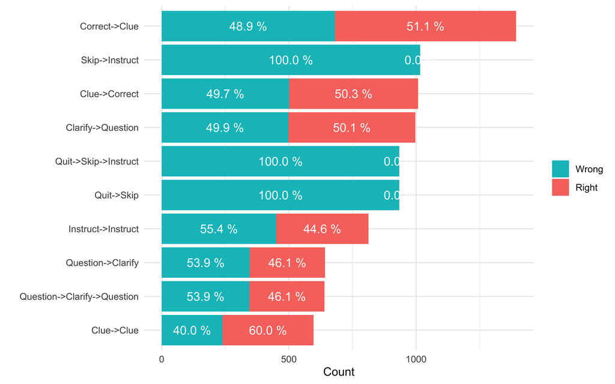

```r
plot(ngrams_outcome, n = 10)
```

**NoteOutcome comparison columns**

Skip→Instruct (p < 0.001) appears in 1016 Wrong-ending sequences and 0 Right-ending sequences—every student who skips and then receives instruction ultimately fails. The next section quantifies these effects with regression.

# 3 Predicting Outcomes from Patterns

**NoteHow analyze_outcome() works**

Three steps:

1. **Pattern discovery**: calls `discover_patterns()` with the specified `type`, `len`, etc.
2. **Selection**: ranks patterns by the `priority` criterion (`"chisq"`, `"lift"`, or `"support"`) and picks the top `n`.
3. **Model fitting**: encodes each pattern as binary (0/1, when `freq = FALSE`) or as within-sequence count (when `freq = TRUE`), then fits `glm()` (or `lme4::glmer()` when `mixed = TRUE`).

The returned object is a standard `glm` or `glmerMod`, so `summary()`, `coef()`, `AIC()`, `predict()`, and `confint()` all work.

## 3.1 Binary predictors: presence/absence of a certain state. If students receive a clue would it help them get the answer correct?

Each selected pattern becomes a 0/1 predictor:

```r
model_binary <- analyze_outcome(
  codyna_data,
  outcome = "last_obs",
  reference = "Wrong",
  n = 5,
  freq = FALSE,
  priority = "chisq",
  type = "ngram",
  len = 1:2,
  mixed = FALSE
)
summary(model_binary)
```

```
Call:
glm(formula = f, family = binomial, data = df)

Coefficients:
                     Estimate Std. Error z value             Pr(>|z|)
(Intercept)           0.00564    0.04514    0.12              0.90058
Quit                 -5.03463    0.41466  -12.14 < 0.0000000000000002 ***
Instruct             -0.03506    0.08240   -0.43              0.67046
Clue_to_Clue          0.40243    0.09233    4.36             0.000013 ***
Question_to_Guide    -0.51225    0.13511   -3.79              0.00015 ***
Instruct_to_Instruct  0.02576    0.10314    0.25              0.80281
---
Signif. codes:  0 '***' 0.001 '**' 0.01 '*' 0.05 '.' 0.1 ' ' 1

(Dispersion parameter for binomial family taken to be 1)

    Null deviance: 6771.5  on 4999  degrees of freedom
Residual deviance: 5642.7  on 4994  degrees of freedom
AIC: 5655

Number of Fisher Scoring iterations: 7
```

`analyze_outcome()` looked at all unigrams and bigrams, ranked them by chi-squared, picked the top 5, and fit a logistic regression using them as 0/1 predictors. `reference = "Wrong"` means positive coefficients increase the odds of Right (success). Converting to odds ratios:

```r
odds_ratios <- exp(coef(model_binary))

data.frame(
  Pattern = names(odds_ratios),
  `Log-Odds` = round(coef(model_binary), 3),
  `Odds Ratio` = round(odds_ratios, 3),
  row.names = NULL, check.names = FALSE
)
```

| Pattern | Log-Odds | Odds Ratio |
| --- | --- | --- |
| (Intercept) | 0.006 | 1.006 |
| Quit | -5.035 | 0.007 |
| Instruct | -0.035 | 0.966 |
| Clue_to_Clue | 0.402 | 1.495 |
| Question_to_Guide | -0.512 | 0.599 |
| Instruct_to_Instruct | 0.026 | 1.026 |

Coefficients as log-odds and odds ratios

**NoteReading logistic regression output**

## 3.2 Frequency-based predictors. Here we take into account the counts, we don’t only count presence but also how frequent. Are more clues useful?

Setting `freq = TRUE` uses within-sequence pattern counts instead of 0/1:

```r
model_freq <- analyze_outcome(
  codyna_data,
  outcome = "last_obs",
  reference = "Wrong",
  n = 10,
  freq = TRUE,
  priority = "chisq",
  type = "ngram",
  len = 1:2,
  mixed = FALSE
)
summary(model_freq)
```

```
Call:
glm(formula = f, family = binomial, data = df)

Coefficients:
                     Estimate Std. Error z value             Pr(>|z|)
(Intercept)           -0.2109     0.0730   -2.89               0.0038 **
Quit                  -4.6488     0.4190  -11.09 < 0.0000000000000002 ***
Clue                  -0.0317     0.0672   -0.47               0.6377
Correct                0.0999     0.0827    1.21               0.2275
Instruct              -0.2151     0.0904   -2.38               0.0173 *
Question_to_Instruct   0.5310     0.1148    4.63         0.0000037146 ***
Correct_to_Correct     0.2755     0.1455    1.89               0.0582 .
Clue_to_Clue           0.5759     0.1147    5.02         0.0000005160 ***
Guide_to_Guide         0.5571     0.0951    5.86         0.0000000047 ***
Question_to_Guide     -0.2534     0.1453   -1.74               0.0811 .
Instruct_to_Instruct   0.3264     0.1292    2.53               0.0115 *
---
Signif. codes:  0 '***' 0.001 '**' 0.01 '*' 0.05 '.' 0.1 ' ' 1

(Dispersion parameter for binomial family taken to be 1)

    Null deviance: 6771.5  on 4999  degrees of freedom
Residual deviance: 5581.7  on 4989  degrees of freedom
AIC: 5604

Number of Fisher Scoring iterations: 7
```

## 3.3 Gapped pattern predictors

```r
model_gapped <- analyze_outcome(
  codyna_data,
  outcome = "last_obs",
  reference = "Wrong",
  n = 5,
  freq = FALSE,
  priority = "chisq",
  type = "gapped",
  gap = 1,
  len = 2,
  mixed = FALSE
)
summary(model_gapped)
```

```
Call:
glm(formula = f, family = binomial, data = df)

Coefficients:
                         Estimate Std. Error z value             Pr(>|z|)
(Intercept)               -0.1768     0.0388   -4.56         0.0000052086 ***
Quit_to_._to_Instruct     -4.8847     0.4113  -11.88 < 0.0000000000000002 ***
Clue_to_._to_Correct       0.5469     0.1188    4.60         0.0000041943 ***
Correct_to_._to_Clue       0.4285     0.0850    5.04         0.0000004597 ***
Clarify_to_._to_Instruct   0.9209     0.1534    6.00         0.0000000019 ***
Guide_to_._to_Guide        1.2755     0.2110    6.05         0.0000000015 ***
---
Signif. codes:  0 '***' 0.001 '**' 0.01 '*' 0.05 '.' 0.1 ' ' 1

(Dispersion parameter for binomial family taken to be 1)

    Null deviance: 6771.5  on 4999  degrees of freedom
Residual deviance: 5580.7  on 4994  degrees of freedom
AIC: 5593

Number of Fisher Scoring iterations: 7
```

AIC = 5592.7, the lowest of the three. Clue→*→Correct captures the delayed hint effect; Guide→*→Guide captures returning to guidance after a detour.

## 3.4 Priority selection

The `priority` parameter controls which patterns enter the regression:

```r
model_lift <- analyze_outcome(
  codyna_data,
  outcome = "last_obs", reference = "Wrong",
  n = 5, freq = FALSE, priority = "lift",
  type = "ngram", len = 1:2, mixed = FALSE
)
model_support <- analyze_outcome(
  codyna_data,
  outcome = "last_obs", reference = "Wrong",
  n = 5, freq = FALSE, priority = "support",
  type = "ngram", len = 1:2, mixed = FALSE
)
```

Table 2: Priority selection guide

| Priority | Selects for | AIC | Use when |
| --- | --- | --- | --- |
| `"chisq"` | Maximum group differentiation | 5654.7 | Outcome prediction is the goal |
| `"lift"` | Over-representation relative to marginals | 6473 | Seeking structurally surprising patterns |
| `"support"` | Most common patterns overall | 6316.3 | Describing typical behavior |

## 3.5 Mixed-effects models

When students solve multiple problems or are nested within classrooms, observations are not independent. `mixed = TRUE` adds a random intercept per group. This is very useful when you have multiple sessions from the same student, or multiple sequences and so on. Codyna has an advanced mixed effect model that takes this into account.

```r
model_mixed <- analyze_outcome(
  raw_data, cols = T1:T10,
  group = student_id,
  outcome = "last_obs",
  reference = "Wrong",
  n = 5,
  freq = FALSE,
  priority = "chisq",
  type = "ngram",
  len = 1:2,
  mixed = TRUE
)
summary(model_mixed)
```

```
Generalized linear mixed model fit by maximum likelihood (Laplace
  Approximation) [glmerMod]
 Family: binomial  ( logit )
Formula: .outcome ~ Quit + Instruct + Clue_to_Clue + Question_to_Guide +
    Instruct_to_Instruct + (1 | student_id)
   Data: df

      AIC       BIC    logLik -2*log(L)  df.resid
     5653      5699     -2820      5639      4993

Scaled residuals:
   Min     1Q Median     3Q    Max
-1.279 -0.964 -0.077  0.961 12.346

Random effects:
 Groups     Name        Variance Std.Dev.
 student_id (Intercept) 0.151    0.389
Number of obs: 5000, groups:  student_id, 3937

Fixed effects:
                     Estimate Std. Error z value             Pr(>|z|)
(Intercept)           0.00615    0.04705    0.13               0.8961
Quit                 -5.09947    0.41717  -12.22 < 0.0000000000000002 ***
Instruct             -0.03721    0.08553   -0.44               0.6635
Clue_to_Clue          0.41435    0.09596    4.32             0.000016 ***
Question_to_Guide    -0.52008    0.14000   -3.71               0.0002 ***
Instruct_to_Instruct  0.03076    0.10712    0.29               0.7740
---
Signif. codes:  0 '***' 0.001 '**' 0.01 '*' 0.05 '.' 0.1 ' ' 1

Correlation of Fixed Effects:
            (Intr) Quit   Instrc Cl_t_C Qst__G
Quit        -0.012
Instruct    -0.486 -0.134
Clue_to_Clu -0.414  0.012  0.136
Questn_t_Gd -0.251  0.026  0.017  0.112
Instrct_t_I -0.024  0.096 -0.590  0.023  0.070
```

- **Random intercept variance** (0.15): captures student-level differences in baseline success probability. A standard deviation of 0.39 means students differ substantially in their baseline ability.
- **Fixed effects**: same interpretation as standard logistic regression, but adjusted for nesting.

```r
cat("AIC (fixed, no nesting):", round(AIC(model_binary), 1), "\n")
```

```
AIC (fixed, no nesting): 5655
```

```r
cat("AIC (mixed, student nesting):", round(AIC(model_mixed), 1), "\n")
```

```
AIC (mixed, student nesting): 5653
```

**NoteWhen to use mixed-effects models**

Standard logistic regression assumes independence. In educational data, this is often violated: the same student solves multiple problems, or students are nested within classrooms. Ignoring nesting inflates the effective sample size, producing artificially small standard errors.

A mixed-effects model (via `lme4::glmer()`) adds a random intercept per group—capturing group-level baselines so that the fixed effects represent *within-group* pattern effects. Use it when:

- The same participant appears in multiple sequences
- Students are nested within classrooms, schools, or conditions
- The random intercept variance is non-trivial

# 4 Sequence Indices

Sequence indices in codyna are designed for educational contexts and build on complex dynamic system theory. Patterns identify *which* pathways students follow. Indices characterize *how* each trajectory unfolds—its diversity, stability, dynamism, and complexity—without reference to any specific pattern. We switch to the built-in `engagement` dataset (1,000 students, 3 states, 25 time points) for richer distributions. As with every dataset in this tutorial, we visualize first.

```r
data("engagement")
```

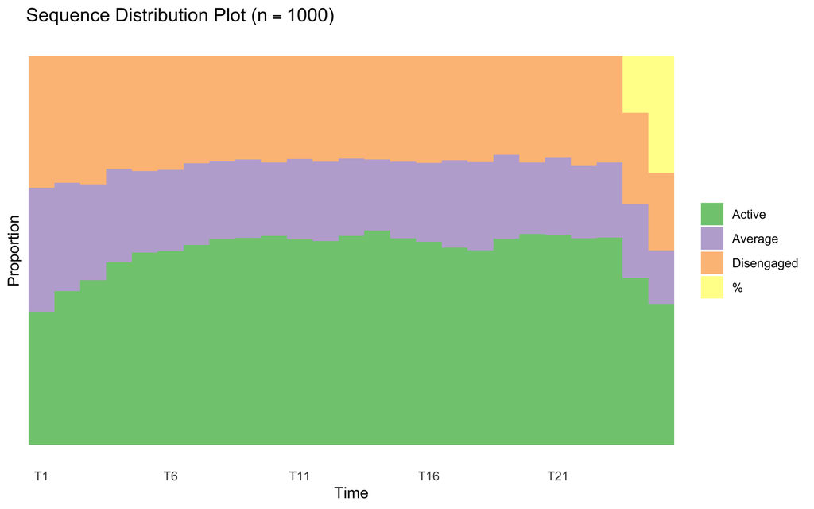

```r
plot_sequences(engagement, type = "distribution", scale = "proportion")
```

```r
indices <- sequence_indices(engagement, favorable = "Active")
numeric_indices <- indices[, sapply(indices, is.numeric)]
summary_df <- data.frame(
  Index = names(numeric_indices),
  Min = round(sapply(numeric_indices, min, na.rm = TRUE), 3),
  Median = round(sapply(numeric_indices, median, na.rm = TRUE), 3),
  Mean = round(sapply(numeric_indices, mean, na.rm = TRUE), 3),
  Max = round(sapply(numeric_indices, max, na.rm = TRUE), 3),
  row.names = NULL
)
summary_df
```

| Index | Min | Median | Mean | Max |
| --- | --- | --- | --- | --- |
| valid_n | 23.00 | 25.00 | 24.55 | 25.00 |
| valid_proportion | 1.00 | 1.00 | 1.00 | 1.00 |
| unique_states | 1.00 | 3.00 | 2.88 | 3.00 |
| mean_spell_duration | 1.79 | 3.83 | 4.70 | 25.00 |
| max_spell_duration | 4.00 | 10.00 | 10.68 | 25.00 |
| longitudinal_entropy | 0.00 | 0.66 | 0.61 | 0.79 |
| simpson_diversity | 0.00 | 0.55 | 0.51 | 0.67 |
| self_loop_tendency | 0.46 | 0.77 | 0.77 | 1.00 |
| transition_rate | 0.00 | 0.23 | 0.23 | 0.54 |
| transition_complexity | 0.00 | 0.67 | 0.60 | 1.00 |

[output cut: 10 more lines]

Summary statistics for all numeric sequence indices

`favorable = "Active"` designates Active as the target for directional indices like `integrative_potential` (convergence toward the favorable state) and `emergent_state_proportion`.

## 4.1 Index families

The 24 indices group into 10 families:

Table 3: Index families and their research questions

| Family | Indices | Question |
| --- | --- | --- |
| Coverage | `valid_n`, `valid_proportion` | How complete is the sequence? |
| Diversity | `unique_states`, `longitudinal_entropy`, `simpson_diversity` | How spread is time across states? |
| Stability | `self_loop_tendency`, `mean_spell_duration`, `max_spell_duration` | How persistent are state episodes? |
| Dynamism | `transition_rate`, `transition_complexity` | How frequent and diverse are transitions? |
| Initial conditions | `initial_state_persistence`, `initial_state_proportion`, `initial_state_influence_decay` | How influential is the starting state? |
| Cyclicity | `cyclic_feedback_strength` | Return patterns? |
| Dominance | `dominant_state`, `dominant_proportion`, `dominant_max_spell` | Which state dominates? |
| First/Last | `first_state`, `last_state` | Boundary conditions |
| Emergence | `emergent_state`, `emergent_state_persistence`, `emergent_state_proportion` | Late-appearing dominant state? |
| Integrative | `integrative_potential`, `complexity_index` | Convergence and complexity |

**NoteDetailed index definitions**

**Coverage**: `valid_n` = non-missing time points; `valid_proportion` = fraction of complete observations.

**Diversity**: `unique_states` = distinct states visited. `longitudinal_entropy` = $-\sum p_i \log p_i$; maximized when all states equally visited. `simpson_diversity` = $1 - \sum p_i^2$; gives less weight to rare states.

**Stability**: `self_loop_tendency` = proportion of consecutive pairs where state does not change. `mean_spell_duration` = average run length. `max_spell_duration` = longest run.

**Dynamism**: `transition_rate` = 1 − self_loop_tendency. `transition_complexity` = entropy of the transition distribution; distinguishes toggling between two states (low) from cycling through many (high).

**Initial conditions**: `initial_state_persistence` = consecutive time points in first state. `initial_state_proportion` = fraction of sequence in first state. `initial_state_influence_decay` = exponential decay rate of first state’s autocorrelation.

**Cyclicity**: `cyclic_feedback_strength` = tendency to revisit previously visited states.

**Dominance**: `dominant_state` = most prevalent state. `dominant_proportion` = its share. `dominant_max_spell` = its longest run.

**Emergence**: `emergent_state` = state dominating the second half. When different from the first-half dominant, a phase transition occurred. `emergent_state_persistence` and `emergent_state_proportion` quantify its hold.

**Integrative**: `integrative_potential` = convergence toward the `favorable` state over time. `complexity_index` = composite of entropy and transition complexity.

# 5 Decision Workflow

1. **Visualize** — `plot_sequences()` and `plot_frequencies()` for raw data exploration.
2. **Discover patterns** — `discover_patterns()` with n-grams, gapped, and repeated types; use `start`, `end`, `contain` to focus.
3. **Compare across outcomes** — add `outcome = ...` to identify group-differentiating patterns.
4. **Model outcomes** — `analyze_outcome()` for logistic regression; `mixed = TRUE` for nested data.
5. **Compute indices** — `sequence_indices()` for per-sequence structural summaries.
6. **Interpret together** — a coefficient is more trustworthy when the pattern is both statistically significant (chi-squared) and structurally meaningful (lift > 1, high support), and the index profile is consistent.

# References

## LA Methods Chapters

### Sequence Analysis and Temporal Methods

- Saqr, M., López-Pernas, S., Helske, S., Durand, M., Murphy, K., Studer, M., & Ritschard, G. (2024). Sequence analysis in education: Principles, technique, and tutorial with R. In M. Saqr & S. López-Pernas (Eds.), *Learning analytics methods and tutorials: A practical guide using R* (pp. 267–298). Springer. https://lamethods.org/book1/chapters/ch10-sequence-analysis/ch10-seq.html
- Helske, J., Helske, S., Saqr, M., López-Pernas, S., & Murphy, K. (2024). A modern approach to transition analysis and process mining with Markov models in education. In M. Saqr & S. López-Pernas (Eds.), *Learning analytics methods and tutorials: A practical guide using R* (pp. 331–362). Springer. https://lamethods.org/book1/chapters/ch12-markov/ch12-markov.html
- López-Pernas, S., Saqr, M., Helske, S., & Murphy, K. (2024). Multi-channel sequence analysis in educational research: An introduction and tutorial with R. In M. Saqr & S. López-Pernas (Eds.), *Learning analytics methods and tutorials: A practical guide using R* (pp. 363–400). Springer. https://lamethods.org/book1/chapters/ch13-multichannel/ch13-multi.html

### Transition Network Analysis

- Saqr, M., López-Pernas, S., & Tikka, S. (2025). Mapping relational dynamics with transition network analysis: A primer and tutorial. In M. Saqr & S. López-Pernas (Eds.), *Advanced learning analytics methods*. Springer. https://lamethods.org/book2/chapters/ch15-tna/ch15-tna.html
- Saqr, M., López-Pernas, S., & Tikka, S. (2025). Capturing the breadth and dynamics of the temporal processes with frequency transition network analysis: A primer and tutorial. In M. Saqr & S. López-Pernas (Eds.), *Advanced learning analytics methods*. Springer. https://lamethods.org/book2/chapters/ch16-ftna/ch16-ftna.html
- López-Pernas, S., Tikka, S., & Saqr, M. (2025). Mining patterns and clusters with transition network analysis: A heterogeneity approach. In M. Saqr & S. López-Pernas (Eds.), *Advanced learning analytics methods*. Springer. https://lamethods.org/book2/chapters/ch17-tna-clusters/ch17-tna-clusters.html

### Complex Dynamic Systems

- Saqr, M., Dever, D., López-Pernas, S., Gernigon, C., Marchand, G., & Kaplan, A. (2025). Complex dynamic systems in education: Beyond the static, the linear and the causal reductionism. In M. Saqr & S. López-Pernas (Eds.), *Advanced learning analytics methods*. Springer. https://lamethods.org/book2/chapters/ch12-cds/ch12-cds.html
- Saqr, M., Schreuder, M. J., & López-Pernas, S. (2024). Why educational research needs a complex system revolution that embraces individual differences, heterogeneity, and uncertainty. In M. Saqr & S. López-Pernas (Eds.), *Learning analytics methods and tutorials: A practical guide using R*. Springer. https://lamethods.org/book1/chapters/ch22-conclusion/ch22-conclusion.html

## Package References

- Tikka, S., López-Pernas, S., & Saqr, M. (2025). tna: An R package for Transition Network Analysis. *Applied Psychological Measurement*. https://doi.org/10.1177/01466216251348840
- Saqr, M., López-Pernas, S., Törmänen, T., Kaliisa, R., Misiejuk, K., & Tikka, S. (2025d). Transition Network Analysis: A novel framework for modeling, visualizing, and identifying the temporal patterns of learners and learning processes. In *LAK ’25* (pp. 351–361). ACM. https://doi.org/10.1145/3706468.3706513

## Methodological References

- Abbott, A. (1995). Sequence analysis: New methods for old ideas. *Annual Review of Sociology*, 21(1), 93–113. https://doi.org/10.1146/annurev.so.21.080195.000521
- Agrawal, R., Imielinski, T., & Swami, A. (1993). Mining association rules between sets of items in large databases. In *SIGMOD ’93* (pp. 207–216). ACM. https://doi.org/10.1145/170036.170072
- Bates, D., Mächler, M., Bolker, B., & Walker, S. (2015). Fitting linear mixed-effects models using lme4. *Journal of Statistical Software*, 67(1), 1–48. https://doi.org/10.18637/jss.v067.i01
- Cohen, J. (1988). *Statistical power analysis for the behavioral sciences* (2nd ed.). Lawrence Erlbaum.